# Act_report

As there are number of people who loves dogs and their first choice as a pet is a dog. So, some of them haven't exact knowlegde about the dogs, but want them as a pet. Some of them a issue which is most popular breed or which breed is the most loving one or which stages are the popular one. So this report may fullfill some of requirement of people. As if some one want a dog its totally depends upon them, but if someone want anytype of guidence, may it will help.

So, here the data is investigate with the help of twitter account name WeRateDogs, where WeRateDogs is a Twitter account that rates people's dogs with a humorous comment about the dog. The account was started in 2015 by college student Matt Nelson, and has received international media attention.

So, here i am analysing some of the data based on which predictions justified. So, here the data which was made avilable to me by udacity as a part of my Data Analyst Nanodegree program only included tweets upto 2017-09-1. And then cleaned and filtered by me, so as to predict correct relation as possible as true.

1. first we gonna see which breed has the most popularity-

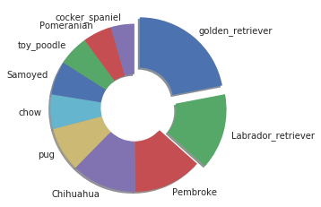

So, here we can a large number of population loves to have the golden_retriver as thier loving pet.

1. We have data also about the source through which number of people ping down thier loves one on the twitter:

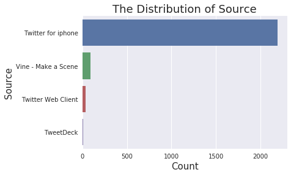

So, as we can see that the most popular way to provide the was the iphone or in other word we can also say that the person having iphone love dogs more as they tweet more as compare to an other source. So, there are many interipretations of above data.

1. Stage distribution of dogs.

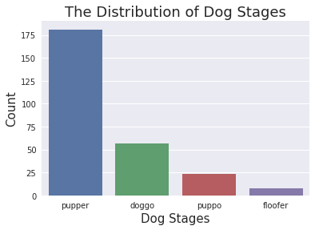

So, here we can that the dogs satges where they are more popular. From the above intrepetations we can say that pupper is the satge where dogs are more popular and least at the satge of floofer. So from here we can also say that the satges of dogs also vary with people choices, some loves to have doggo or some loves the floofer or puppo.

1. Rating variations, which is unique to define loves for dog where numerator rating varies with denomintor fixed.

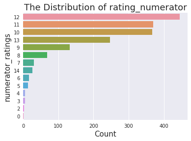

So, here the most popular rating is 12. This rating graph doesn.t show exact relation with dogs but, it explain the rating variation of people love for dog. As in general the people have provided higher rating for numerator than denominator, hence, in genral we can say that the people who went through weratedogs twitter handle provide a good rating irrespective of variation in images.

#### Conclusion

So, from the above visualization we can say that its really depend person to person which breed he/she like or which satge or anything, but in genral, whoever passed through page definately likes dog and provided a good rating. But as we can see the golden_retriver is most famous one and the pupper satge is also the loved ones. So if someone want to make choice he/she can go with that particular breed and its stage.